# Tata

Tata

7/2/2018

## Results

```
##  [1] "X"         "wineyard"  "winetype"  "year"      "posneg"
##  [6] "bottlenum" "quality"   "X1"        "X2"        "X3"
```

```
## [1]  300 5747
```

```
## [1]  300 5747
```

```
## [1] 300 507
```

## Exploratory Data Analysis

To understand the data a bit we can look at the variability of an abundance of a random metabolite in the different types of wine, vineyard and quality. as in the 3 figures below. Some of the things that we can highlight here all 3 boxplots that will be presented here correspond to the same metabolite, one that we chose at random.

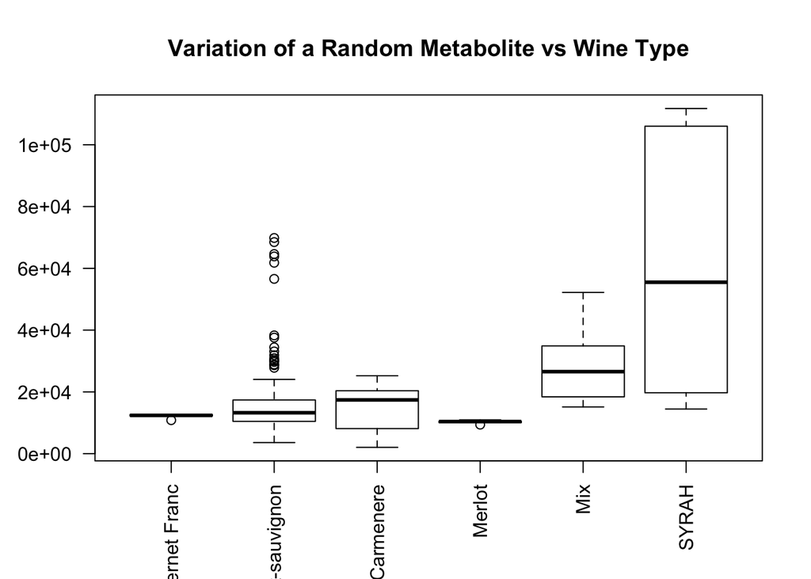

Here we have the different types of wines and we see how this certain metabolite is distributed independently and distinctly from the other wine types, showing variations. this metabolite is found very poorly in Merlot and Cabernet Franc, but is widely spread in the syrah type of wine.

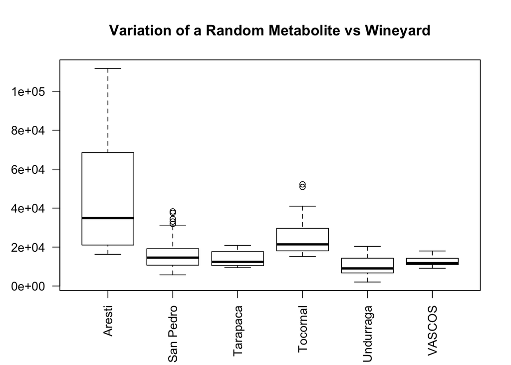

In the case of vineyards, the metabolite is widely distributed in the Aresti wine samples and in the other vineyards it is present in a more or less similar proportion to the other vineyards.

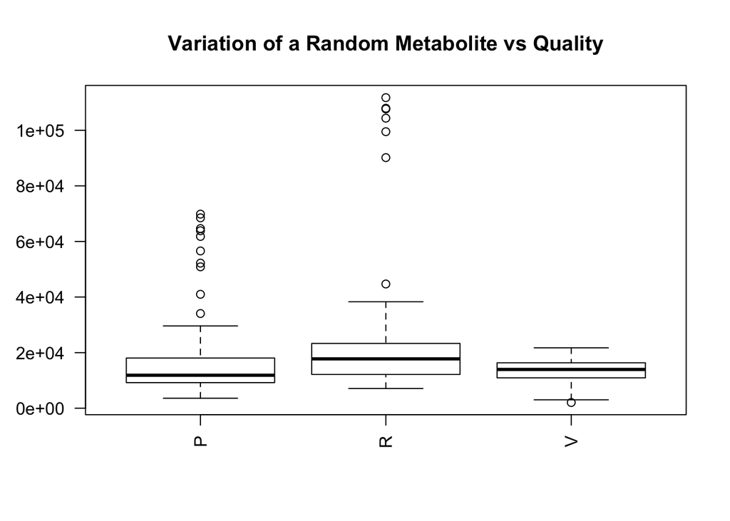

Finally for the case of this random metabolite and its variation in different qualities of wine, we see that the values are slightly skewed and for the high and regular quality of wine also several outliers are observed.

To check if the specific distribution of this metabolite is real and significant and not just some results obtained by chance, we will randomly change the order of the row using the sample() function in R, to randomly change the position of the metabolite values. in this way we will set new random values to each row and see if this distribution gives similar results.

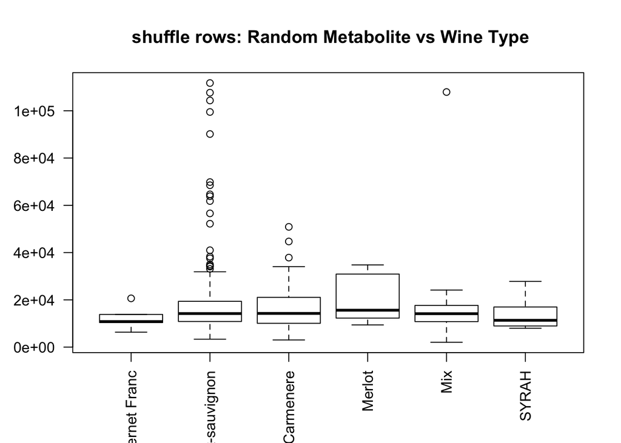

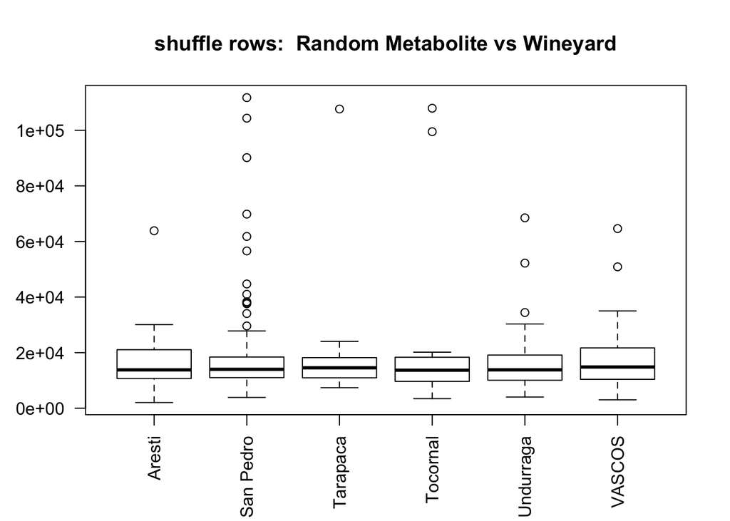

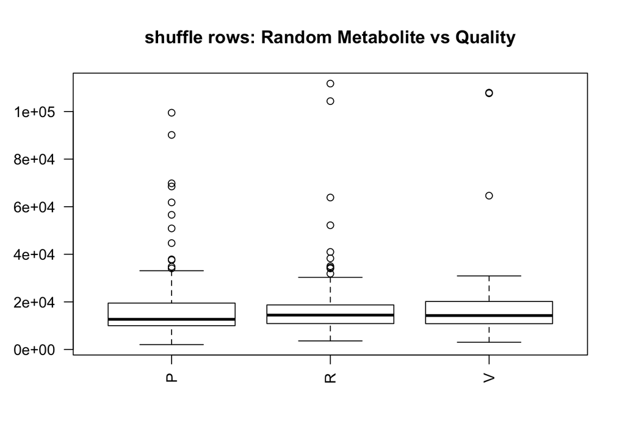

After the shuffling we checked the distribution of the random metabolite in question in relation to the type of wine, the quality and the vineyard, and in all the boxplots we found no variation. i.e. the metabolite values were very similar in each case. This is an indicator that our data correspond to meaningful events and are not the result of random measurements.

## Wines Metabolics Profiles

Based on the visual inspection of the metabolomic profiles for the different types of wine, we observed differences according to the type of wine and the quality. (The relative abundance of metabolites is shown below) visually some metabolites peaks are detectable exclusively in each wine type.

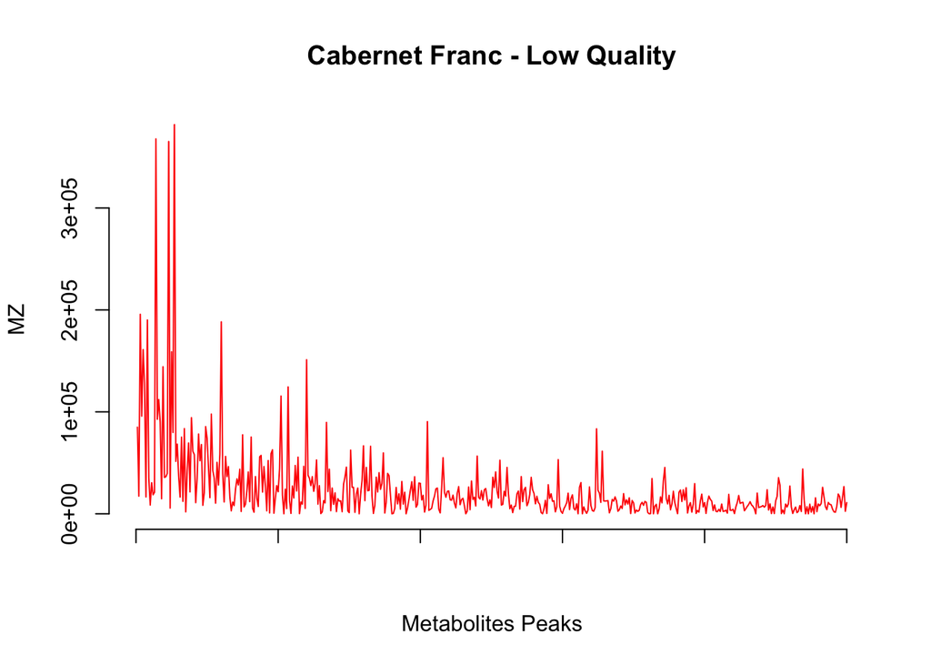

This figure shows the relative abundance of a metabolic sample for Cabernet Franc wines, that are of low quality. If we compare it with Merlot wines (figure below), we can see with the eye a small similarity in the profiles, but the abundance in merlot wines for these metabolisms is higher.

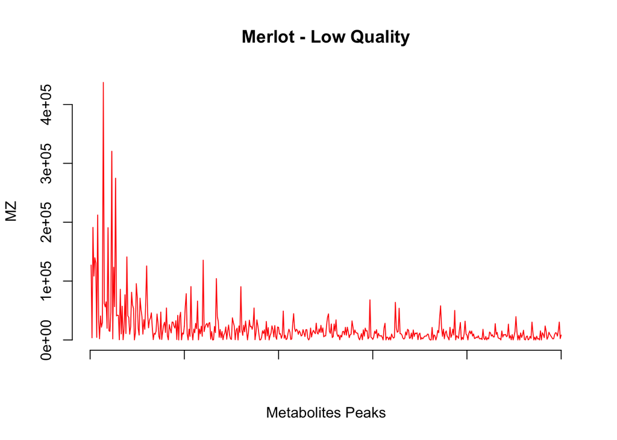

The relative abundance profile for regular quality Syrah wines is shown in the following figure. This profile is slightly different from those of low quality wines seen above but here you can see some peaks that are not seen in the metabolic profiles shown above (profiles of Cabernet Franc and Merlot).

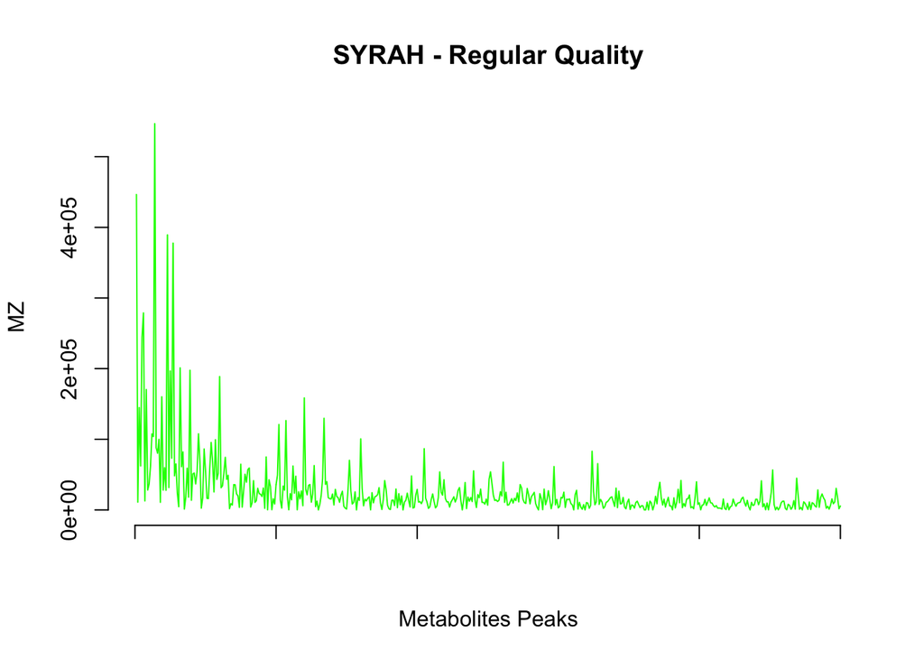

In the following figure, the difference between the profiles of two types of wine quality, from the same brand, is considerably more noticeable. In this figure we have the metabolic profile for the type of mix wine with premium and regular categories respectively. These results are indicators that wines quality determined by a wine expert is related to their metabolomic profile. It is important to clarify that these descriptions are based on the visual comparison of different metabolic profiles but later we will apply clusters techniques to analyze the wines and their quality in more detail.

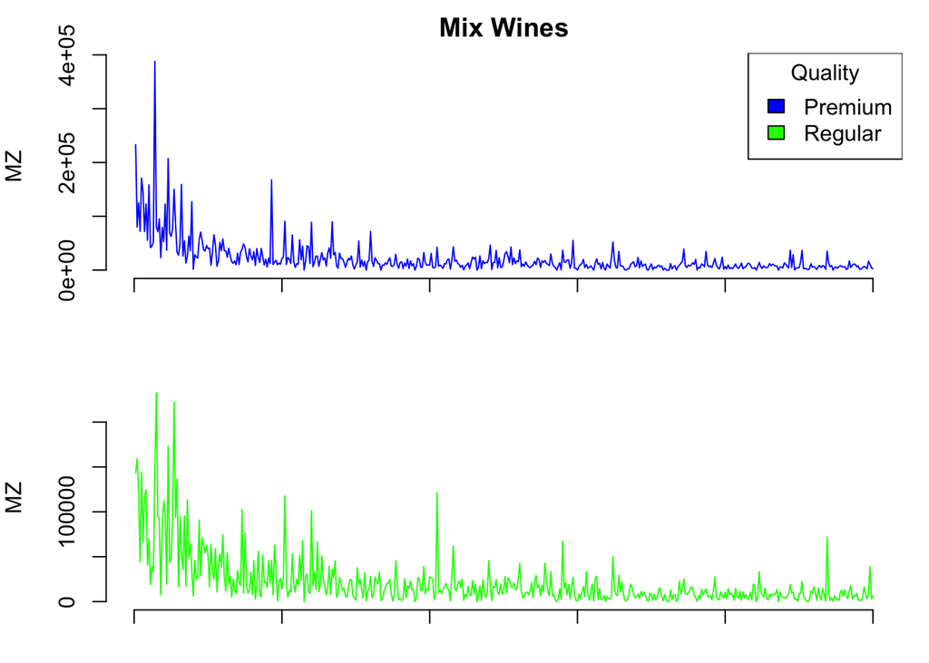

In the case of Carmenere wines, we found that the metabolic profiles of high and regular quality show no strong visible difference in the peaks (some peaks differs), the only difference is in the relative abundance of these peaks (next figure).

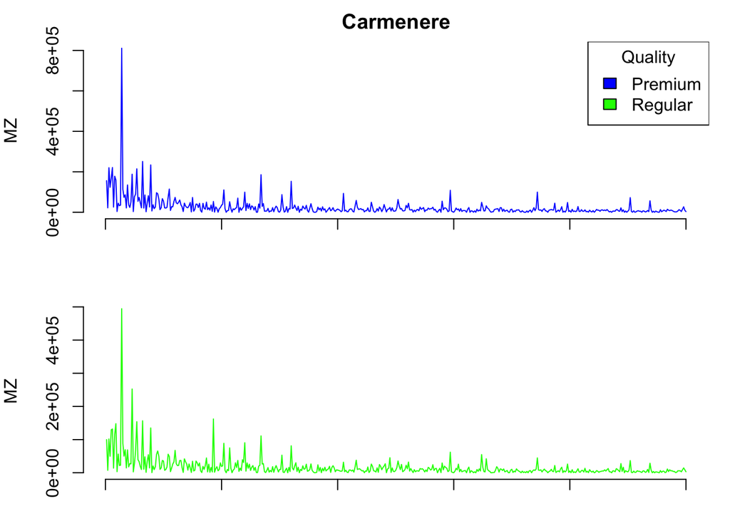

Finally we have the metabolic profiles for the cabernet sauvignon wine. this wine is the only one in our database that contains high, regular and low quality bottles. in the following plot we see the respective profiles. In general, there are small differences, some peaks are more pronounced and more abundant. According to internet data, a bottle of Cacabernet Sauvignon can cost between 5 and 11 euros. With the following analyses we want to check if the price and quality of the wine bottles are related to the metabolism profile. These first comparisons of metabolic profiles serve to make a visual comparison of abundance and distribution metabolites in wine samples and their relationship to wine quality

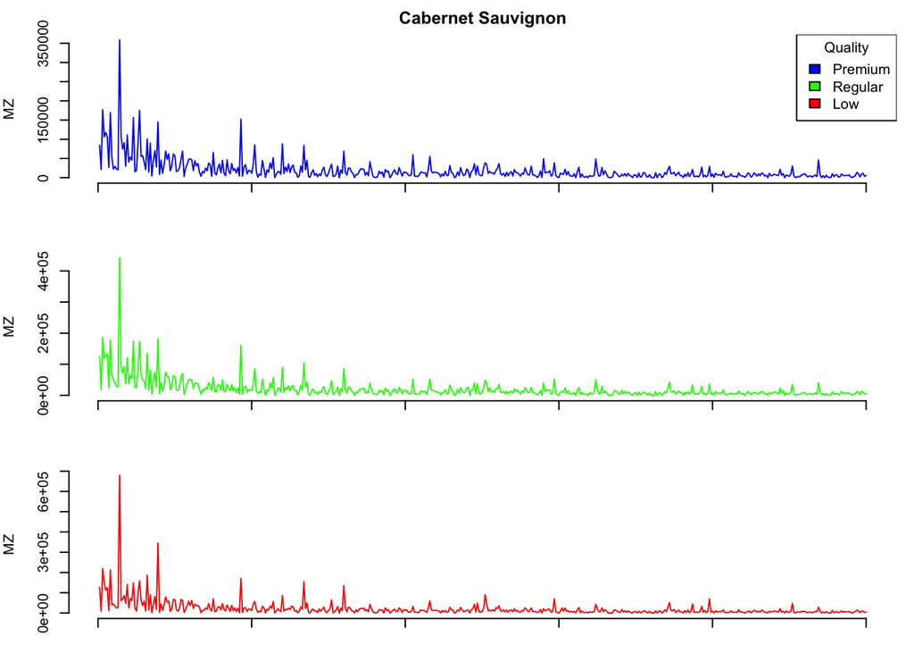